# 统计软件大作业源码

汪胤恒小组

2021/01/16

# 自定义函数

```r
library(jiebaR)
library(readxl)
library(plyr)
library(ggplot2)
library(stringr)
library(wordcloud2)
library(car)
library(zoo)
library(lmtest)
library(MASS)
fen_stop <- function(cutter,txt_w,num = 150,stopword = c()){
  c <- cutter[txt_w] #分词后的列表
  w <- listToDf(c)
  #所有词汇及其词性构成的数据框，“word”“tag”
  wo <- ddply(w,.(word),nrow) #所有词汇及其词频表
  wo = wo[order(wo$V1,decreasing = T),]
  #词频排序
  wo <- wo[1:num,]
  wo <- wo[-which(wo$word %in% stopword),]
  return(wo)
}
listToDf <- function(text_res){
    text = lapply(text_res, as.matrix)
    tag = lapply(text_res,names)
    text_df = as.data.frame(do.call(rbind,text),stringsAsFactors = F)
    tag_df = as.data.frame(do.call(rbind,lapply(tag, as.matrix)),stringsAsFactors = F)
    text_tag_df = cbind(text_df,tag_df)
    colnames(text_tag_df) = c("word","tag")

    tag_choose <- read.csv("tags.csv",header = F,stringsAsFactors = F)[-25,]
    text_tag_df_choose = text_tag_df[which(tag_df$V1 %in% tag_choose$V1),]

    return(text_tag_df_choose)
}
# 回归诊断函数
regression.diagnostics <- function(fit) {
  par(mfrow = c(2, 3))
  plot(fit, which = 1:5)
  influencePlot(fit)

  cat("异常值/强影响点检验\n")
  print(outlierTest(fit))

  cat("\n异方差检验\n")
  print(ncvTest(fit))
  print(bptest(fit))
  print(gqtest(fit))

  cat("\n共线性检验\n")
  print(vif(fit))

  cat("\n自相关检验\n")
  print(durbinWatsonTest(fit))
}
```

# 可视化

```r
#读取数据
taptap_data<-read_xls("taptap_data.xls")
taptap_data$...1<-NULL
#对每个游戏名进行去重操作得到游戏名清单
games<-taptap_data[!duplicated(taptap_data[,1]),]
#查看总评分最低的五个游戏
head(games[order(games[,2],decreasing=F),][,c(1,2)],n=5)
```

```
## # A tibble: 5 x 2
##   游戏名称             总评分
##   <chr>                 <dbl>
## 1 太空杀（测试版）        2.1
## 2 万国觉醒                3.4
## 3 网吧模拟器（测试版）    3.7
## 4 明日之后                4.1
## 5 黑潮之上                4.4
```

```r
#查看总评分最高的五个游戏
head(games[order(games[,2],decreasing=T),][,c(1,2)],n=5)
```

```
## # A tibble: 5 x 2
##   游戏名称                            总评分
##   <chr>                                <dbl>
## 1 纪念碑谷                              10
## 2 2048清（测试版）                       9.9
## 3 信任的进化-合作自私的基因（测试版）    9.8
## 4 艾希                                   9.8
## 5 IRIS（测试版）                         9.8
```

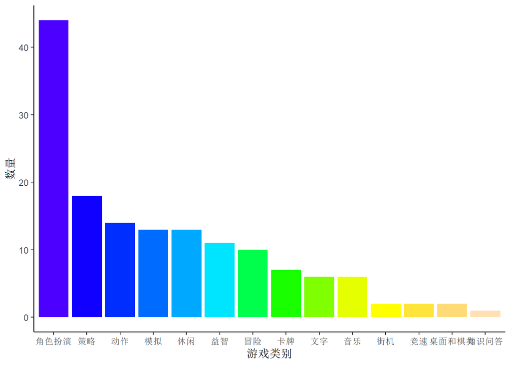

```r
#查看游戏热门榜各游戏类别的数量
p <- ggplot(data=games,mapping = aes(x=reorder(类别,类别,function(x)-length(x))))
p<-p+geom_bar(fill=topo.colors(14,alpha = 1))
p<-p+labs(x="游戏类别",y="数量")
p<-p+theme_classic()
p
```

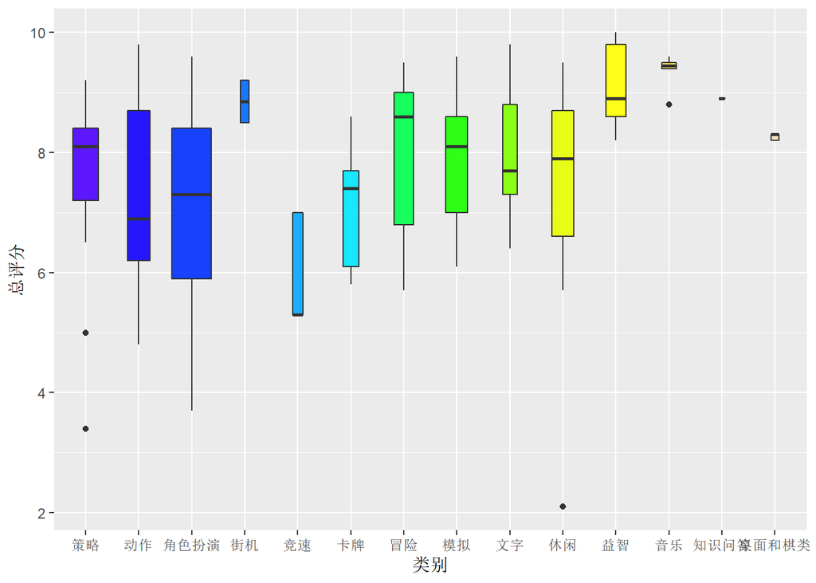

```r
#查看不同游戏类别的评分和受众人数差异
ggplot(taptap_data,aes(x=factor(类别),y=总评分)) + geom_boxplot(alpha=0.9,fill=topo.colors(14,alpha = 0.1),varwidth=TRUE) + xlab("类别")#可以查看不同类别的游戏的评分分布
```

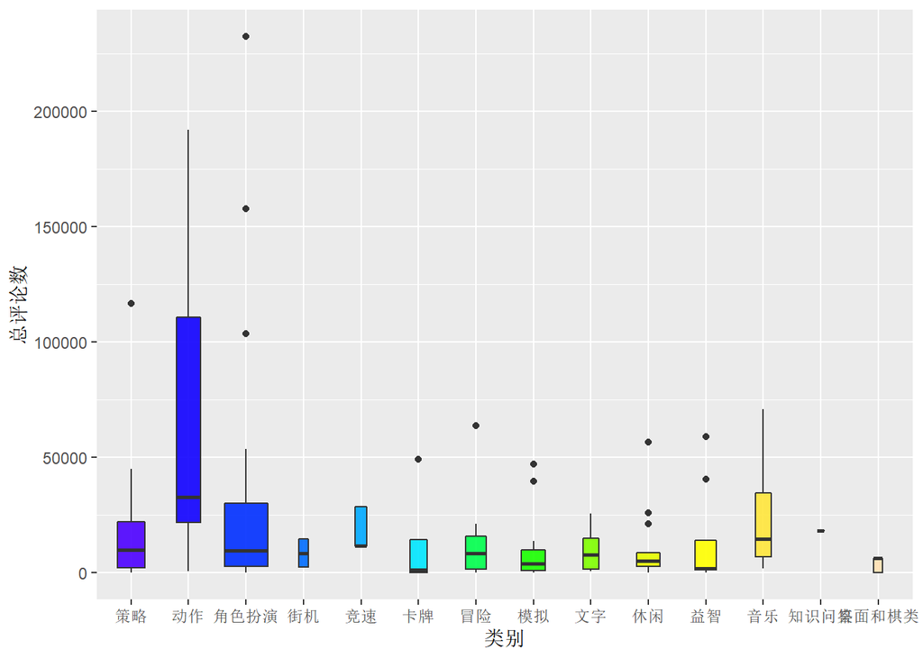

```r
ggplot(taptap_data,aes(x=factor(类别),y=总评论数)) + geom_boxplot(alpha=0.9,fill=topo.colors(14,alpha = 0.1),varwidth=TRUE) + xlab("类别")
```

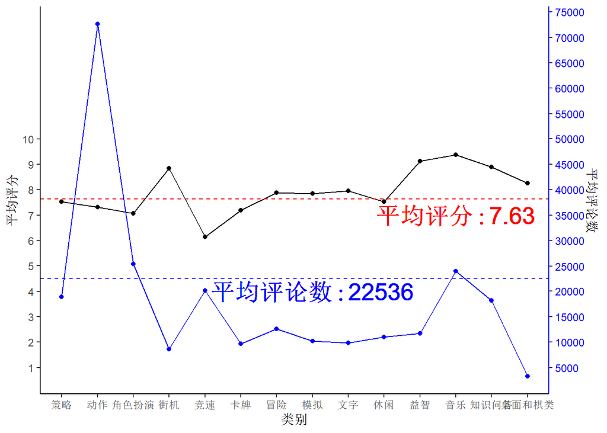

```r
#查看不同类型游戏的平均评分,平均评论数
ave_score<-ddply(games,.(类别),function(x){mean(x$总评分)})
ave_comments<-ddply(games,.(类别),function(x){mean(x$总评论数)})
colnames(ave_score)<-c("类别","分类评分")
colnames(ave_comments)<-c("类别","分类评论数")
games<-merge(games,ave_score,by="类别")
games<-merge(games,ave_comments,by="类别")
p1 <- ggplot(data=games,mapping = aes(x=类别))
p1<-p1+geom_point(aes(y=分类评分),colour="black")
p1<-p1+geom_line(aes(y=分类评分),group=1,colour="black")
p1<-p1+scale_y_continuous(name="平均评分",breaks=seq(1,10,1),sec.axis = sec_axis(~.*5000,name = "平均评论数",breaks=seq(5000,75000,5000),labels=seq(5000,75000,5000)))  #设置一下主副轴刻度
p1<-p1+theme(axis.text.y.right = element_text(colour =rep("blue",times=15)))
p1<-p1+theme(axis.line.y.right = element_line(colour ="blue"))
p1<-p1+geom_point(aes(y=分类评论数/5000),colour="blue")
p1<-p1+geom_line(aes(y=分类评论数/5000),group=1,colour="blue")
p1<-p1+geom_hline(yintercept = mean(games$总评分),,colour="red",lty=2)
p1<-p1+geom_text(aes(x="音乐",y=7),label='平均评分:7.63',parse = TRUE, size=7,colour="red")
p1<-p1+geom_hline(yintercept = mean(games$总评论数/5000),,colour="blue",lty=2)
p1<-p1+geom_text(aes(x="模拟",y=4),label='平均评论数:22536',parse = TRUE, size=7,colour="blue")
p1<-p1+theme_classic()
p1<-p1+theme(axis.text.y.right = element_text(colour =rep("blue",times=15)))
p1<-p1+theme(axis.line.y.right = element_line(colour ="blue"))
p1
```

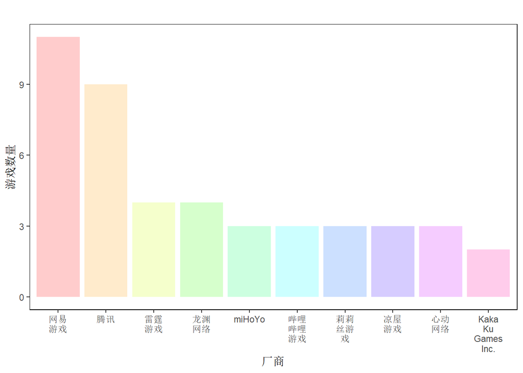

```r
#查看热门游戏的厂商分布情况
a1 <- ddply(ddply(games,.(游戏名称,厂商),nrow),.(厂商),nrow) #统计每一个厂商的游戏数量
b1 <- a1[order(a1$V1,decreasing = T),]
colnames(b1) <- c("productor","number")
b1$productor <- factor(b1$productor,levels = b1$productor)
ggplot(b1[1:10,],mapping = aes(x = productor, #仅绘制前十的游戏厂商
                               y = number,
                               fill = factor(productor,levels = b1$productor[1:10])))+
  geom_bar(stat = "identity") +
  scale_fill_manual(values = rainbow(10,alpha = 0.2)[1:10])+
  theme(legend.position = "None",panel.background=element_rect(fill="white",color="black"),#白底黑框
        panel.grid = element_blank())+
  scale_x_discrete(labels = function(x){str_wrap(x,width = 4)})+
  ggtitle("")+
  labs(x = "厂商",y = "游戏数量")
```

```r
#标签分词,查看标签内前50的关键词,从中看出主流游戏有些什么元素
stop_words<-read.table("stopwords.dat",encoding = "UTF-8")
stop_words<-c(stop_words,"的","","你","在","是","和","了","中","与","都","有","将","也","会","等","更","群","不","为","上","让","人","我","被","由","多","而","您","到","能","就","玩","很","这","说","还","好","给","吧","没","但","要","个","打","啊","看","想","又","把","去","做","对","游戏","没有","觉得","这个","还是","还有","但是","所以","可以","真的","时候","就是","现在","什么","不过","其他","问题","我们","玩家","自己","每","后","一个","可能","怎么","不是","如果","需要","呢","而且","因为","那么","有点","你们","一次","虽然","感觉","其实","这么","的话","应该","开始","希望","一点","当然","一起","他","已经","之后","或者","非常","得","级","对于","比较","来说","下","只有","两个","他们","只是","目前","有些","一些","挺","小时","这么","很多","不要","起来","剧情","来着","再","东西","一下","然后","知道","着","再","太","确实","过","只","里","不能","")
game_labels<-games$标签
wk<- worker(bylines = TRUE)
labels_fenci<-wk[game_labels]
segmented.comments <- segment(game_labels, wk)
head(labels_fenci)
```

```
## [[1]]
## [1] "付费" "三国" "单机"
##
## [[2]]
## [1] "MOBA" "联机" "多人"
##
## [[3]]
## [1] "模拟" "策略" "战争"
##
## [[4]]
## [1] "UP"        "主"        "推荐"      "地牢"      "Roguelike"
##
## [[5]]
## [1] "美少女" "策略"   "二次元"
##
## [[6]]
## [1] "单机" "有毒" "生存"
```

```r
wk1<-worker()
labels_fenci2<-wk1[game_labels]
labels_stop<-filter_segment(labels_fenci2,stop_words)  #过滤掉停用词
f<-as.data.frame(table(labels_stop))  #table分类，查看频数
f<-f[sort(f$Freq,index.return=T,decreasing = T)$ix,]  #降序排序
head(f,n=50)  #查看前50行
```

```
##     labels_stop Freq
## 28         单机   31
## 38       二次元   17
## 99         竖屏   16
## 41         放置   15
## 119        养成   15
## 69         卡牌   14
## 74         联机   14
## 59     角色扮演   13
## 22         策略   12
## 64         经营   11
## 13    Roguelike    8
## 48         挂机    8
## 82         模拟    8
## 95         生存    8
```

[output cut: 36 more lines]

```r
#由于未知bug，rmd无法显示多个词云图，用网页制作标签词云

#评论分词
comments<-taptap_data$compre
comments_fenci<-wk1[comments]
comments_stop<-filter_segment(comments_fenci,stop_words)  #过滤掉停用词
f1<-as.data.frame(table(comments_stop))  #table分类，查看频数
f1<-f1[sort(f1$Freq,index.return=T,decreasing = T)$ix,]  #降序排序
head(f1,n=50)  #查看前50行
```

```
##       comments_stop Freq
## 32027            氪 7238
## 50034          时间 3544
## 39850            那 3416
## 59934          喜欢 3339
## 28874            金 3092
## 32976            来 3016
## 57066          玩法 2984
## 13810            点 2916
## 67299            用 2894
## 54575          体验 2829
## 5864           不错 2712
## 71233          这样 2710
## 64926            一 2707
## 75211          最后 2703
```

[output cut: 36 more lines]

```r
#由于未知bug，rmd无法显示多个词云图，用网页制作评论词云

#简介分词
intro<-taptap_data$intropre
intro_fenci<-wk1[intro]
intro_stop<-filter_segment(intro_fenci,stop_words)  #过滤掉停用词
f2<-as.data.frame(table(intro_stop))  #table分类，查看频数
f2<-f2[sort(f2$Freq,index.return=T,decreasing = T)$ix,]  #降序排序
head(f2,n=50)  #查看前50行
```

```
##      intro_stop  Freq
## 5192       世界 17271
## 5643       体验 11809
## 7323       战斗 10817
## 5873       玩法 10159
## 2156       官方  9896
## 2127       故事  8092
## 6730       一款  7279
## 656        不同  7196
## 1            　  7192
## 2872       角色  7119
## 5285       手游  6479
## 3845       冒险  6281
## 5565       探索  6155
## 5731       通过  6096
```

[output cut: 36 more lines]

```r
#由于未知bug，rmd无法显示多个词云图，用网页制作简介词云

#游戏的评论星级
F1<-grep(pattern="(氪)",taptap_data$compre)
q1<-mean(taptap_data$评论星级[F1])
F2<-grep(pattern="(剧情)",taptap_data$compre)
q2<-mean(taptap_data$评论星级[F2])
F3<-grep(pattern="(时间)",taptap_data$compre)
q3<-mean(taptap_data$评论星级[F3])
F4<-grep(pattern="(玩法)",taptap_data$compre)
q4<-mean(taptap_data$评论星级[F4])
F5<-grep(pattern="(肝)",taptap_data$compre)
q5<-mean(taptap_data$评论星级[F5])
y<-c(q1,q2,q3,q4,q5)
y#[1] 3.362046 3.991752 3.734137 3.859970 3.631807
```

```
## [1] 3.362046 3.991752 3.734137 3.859970 3.631807
```

```r
mean<-mean(taptap_data$评论星级)
mean#[1] 3.733608
```

```
## [1] 3.733608
```

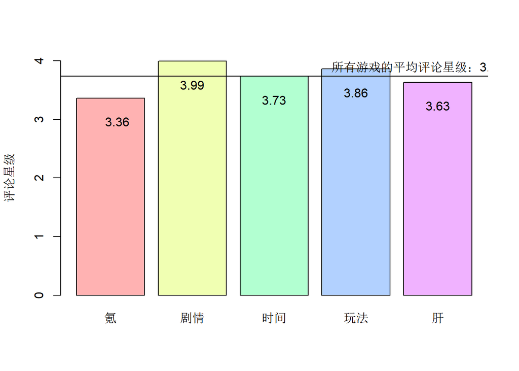

```r
labels<-round(y,2)
names<-c("氪","剧情","时间","玩法","肝")
barplot(y,names.arg=names,col=rainbow(5,alpha=0.3),ylab="评论星级",ylim=c(0,4))
abline(h = mean,col="black")
text(x=c(0.8,1.9,3.1,4.3,5.5),y=y-0.4,labels=labels)
text(5.2,3.9,labels="所有游戏的平均评论星级：3.73",cex=1)
```

```r
#社交类游戏词云和非社交类游戏词云
danji_index <- union(grep("单机",taptap_data$标签),which(taptap_data$总评论数<20000))
ttsub1 <- taptap_data[-danji_index,] #社交类游戏
ttsub2 <- taptap_data[danji_index,] #非社交类游戏
stop <- "C://Users//DELL//Desktop//stopwords.dat"#提供分词器路径
cutter <- worker(bylines = T,stop_word = stop,"tag") #构建分词器
stopword_freq = read.csv("stopwordslist.csv",header = F,stringsAsFactors = F,fileEncoding = "UTF-8")#停用词表
fre_s <- fen_stop(cutter,ttsub1$compre,stopword = stopword_freq$V1) #社交游戏词频
fre_p <- fen_stop(cutter,ttsub2$compre,stopword = stopword_freq$V1)#非社交游戏词频
#使用在线工具绘制词云图

#建立氪度相关的词库
word_kedu <- c("氪","钱","皮肤","抽")

#以评论为单位，统计该条评论是否出现氪金相关词语
tt <- taptap_data
z <- dim(tt)[2]
for(i in 1:4){
  cat(i)
  tt[,z+i] = 0
  tt[grep(word_kedu[i],tt$compre),z+i] = 1
}
```

```
## 1234
```

```r
mean(tt[,14])
```

```
## [1] NA
```

```r
head(tt)
```

```
## # A tibble: 6 x 17
##   游戏名称 总评分 总评论数 厂商  类别  标签  简介  评论id 评论用户 评论内容
##   <chr>     <dbl>    <dbl> <chr> <chr> <chr> <chr>  <dbl> <chr>    <chr>
## 1 人工桌面    8.3     6411 miHo~ 桌面和棋~ 美少女3~ "《人工~ 2.25e7 手机用户667~ <p>一开始看~
## 2 人工桌面    8.3     6411 miHo~ 桌面和棋~ 美少女3~ "《人工~ 2.25e7 麦克老狼 <p>欣赏了一~
## 3 人工桌面    8.3     6411 miHo~ 桌面和棋~ 美少女3~ "《人工~ 2.25e7 莱昂纳多 <p>用了几天~
## 4 人工桌面    8.3     6411 miHo~ 桌面和棋~ 美少女3~ "《人工~ 2.25e7 百战丶人王~ <p>挺喜欢的~
## 5 人工桌面    8.3     6411 miHo~ 桌面和棋~ 美少女3~ "《人工~ 2.25e7 小手冰凉 <p>用了两天~
## 6 人工桌面    8.3     6411 miHo~ 桌面和棋~ 美少女3~ "《人工~ 2.25e7 寂       <p>说一下使~
## # ... with 7 more variables: 评论星级 <dbl>, compre <chr>, intropre <chr>,
## #   ...14 <dbl>, ...15 <dbl>, ...16 <dbl>, ...17 <dbl>
```

```r
class(tt[1,14])
```

```
## [1] "tbl_df"     "tbl"        "data.frame"
```

```r
colnames(tt)[(z+1):(z+4)] <- word_kedu

kedu <- ddply(tt,.(游戏名称,总评分),function(x){
  sum(x$"氪")+sum(x$"钱")*0.3+sum(x$"皮肤")*0.2+sum(x$"抽")*0.5
})
kedu <- kedu[order(kedu$V1,decreasing = T),]

gaokedu_good <- kedu$游戏名称[which(kedu$V1>39 & kedu$总评分 > 8)]#高氪高分游戏
gaokedu_bad <- kedu$游戏名称[which(kedu$V1>39 & kedu$总评分 < 6)] #高氪低分游戏

ttsub4 <- tt[which(tt$游戏名称 %in% gaokedu_good),]
ttsub5 <- tt[which(tt$游戏名称 %in% gaokedu_bad),]

b2 <- fen_stop(cutter,ttsub4$compre,stopword = stopword_freq$V1)#高氪高分游戏词频
b3 <- fen_stop(cutter,ttsub5$compre,stopword = stopword_freq$V1)#高氪低分游戏词频
#使用在线工具绘制词云图
```

# 说明

首先从数据中提取一些衍生变量，然后开始构建模型。两个基本模型分别是以总评分和对数总评论数为因变量，以其他所有变量为自变量（以对数总评论数为因变量时会从自变量中删去社交类游戏，因为该列特征的提取本身用到了总评论数）建立的多元线性回归模型。

总体思路是，对这两个模型，分别深入到某一种分类下的游戏（例如社交类/非社交类，高氪/非高氪，热门/非热门，角色扮演/策略/棋牌/其他……），去对比不同分类下得出的模型结果有没有有意思的、可解释的差异。有上述差异的保留下来，没有的则剔除。

最终，对评分模型，社交类/非社交类，高氪/非高氪这两种分类都能产出有意思的结论。而对评论数模型，每种分类下的模型系数似乎都跟原始模型没有什么大的区别，没有什么有意思的点，因此只保留了原始模型。

除此之外，对每一个模型都做了基础的模型诊断，但仅对模型一在文档中保留了具体的诊断过程，其他模型则省略了诊断过程，仅保留经诊断、处理后的回归结果。

# 建立模型

```r
taptap_data$简介 <- taptap_data$intropre
taptap_data$评论内容 <- taptap_data$compre
taptap_data$总评论数[taptap_data$游戏名称 == "原神"] <- 157998
taptap_data <- taptap_data[-c(1, 9, 10, 13, 14),]
taptap_data <- na.omit(taptap_data)

# 评论分词
分词器 <- worker(stop_word = "stopwords.dat", bylines = TRUE)
segmented.comments <- segment(taptap_data$评论内容, 分词器)
freqs <- freq(unlist(segmented.comments))  # 对所有评论进行词频统计
freqs <- freqs[order(freqs$freq, decreasing = TRUE), ]  # 按词频从高到低排序

# 提取出各游戏
games_data <- taptap_data[!duplicated(taptap_data$游戏名称), 1:7]

# 特征提取
# 是否测试版
games_data$测试版 <- grepl("测试", games_data$游戏名称)
games_data$测试版[which(games_data$测试版 == TRUE)] <- "是"
games_data$测试版[which(games_data$测试版 == FALSE)] <- "否"

# 是否社交类游戏
games_data$社交类游戏 <- games_data$总评论数 > 20000 & !grepl("单机", games_data$标签)
games_data$社交类游戏[which(games_data$社交类游戏 == TRUE)] <- "是"
games_data$社交类游戏[which(games_data$社交类游戏 == FALSE)] <- "否"

# 厂商规模
games_data$厂商规模 <- games_data$厂商 %in% c("网易游戏", "腾讯", "雷霆游戏", "龙渊网络", "miHoYo", "哔哩哔哩游戏", "凉屋游戏", "心动网络")
games_data$厂商规模[which(games_data$厂商规模 == TRUE)] <- "大厂"
games_data$厂商规模[which(games_data$厂商规模 == FALSE)] <- "小厂"

# 厂商类别
games_data$厂商类别 <- games_data$厂商
games_data$厂商类别[which(games_data$厂商类别 == "网易游戏")] = "网易"
games_data$厂商类别[which(games_data$厂商类别 %in% c("雷霆游戏", "龙渊网络", "miHoYo", "哔哩哔哩游戏", "莉莉丝游戏", "凉屋游戏", "心动网络", "Kaka Ku Games Inc."))] = "其他大厂"
games_data$厂商类别[which(!games_data$厂商类别 %in% c("网易", "腾讯", "其他大厂"))] = "小厂"

# 评论平均长度
games_data$评论平均长度 <- rep(0, nrow(games_data))
for (i in 1:nrow(games_data)) {
  name <- games_data$游戏名称[i]
  comments <- taptap_data$评论内容[taptap_data$游戏名称 == name]

  lengths <- 0
  for (j in 1:length(comments)) {
    length <- nchar(comments[j])
    lengths <- lengths + length
  }
  games_data$评论平均长度[i] <- lengths / length(comments)
}

# 词频统计函数
get.total.freqs <- function(word_list, weight_list, feature_name) {
  games_data[, feature_name] <- rep(0, nrow(games_data))

  for (i in 1:nrow(games_data)) {
    name <- games_data$游戏名称[i]
    comments <- taptap_data$评论内容[taptap_data$游戏名称 == name]

    freqs <- 0
    for (j in 1:length(word_list)) {
      count <- length(grep(word_list[j], comments))
      freq <- count / length(comments)
      freqs <- freqs + freq * weight_list[j]
    }
    games_data[i, feature_name] <- freqs
  }

  return(games_data)
}

# 好词总频率
word_list_good <- c("推荐", "剧情", "音乐", "画风", "画面", "难度", "简单")
games_data <- get.total.freqs(word_list_good, rep(1 / length(word_list_good), length(word_list_good)), "好词总频率")

# 坏词总频率
word_list_bad <- c("恶心", "皮肤", "抽", "钱", "氪")
games_data <- get.total.freqs(word_list_bad, rep(1 / length(word_list_bad), length(word_list_bad)), "坏词总频率")

# 氪金指数
word_list_gold <-  c("氪", "抽", "钱", "买", "皮肤")
games_data <- get.total.freqs(word_list_gold, c(0.4, 0.2, 0.2, 0.1, 0.1), "氪金指数")

# 爆肝指数
word_list_liver <-  c("肝", "刷", "小时", "时间")
games_data <- get.total.freqs(word_list_liver, c(0.5, 0.2, 0.2, 0.1), "爆肝指数")

# 游戏机制指数
word_list_mechanics <-  c("剧情", "难度", "玩法", "机制", "设定")
games_data <- get.total.freqs(word_list_mechanics, rep(1 / length(word_list_mechanics), length(word_list_mechanics)), "游戏机制指数")

# 艺术设计指数
word_list_design <-  c("画风", "画面", "界面", "音乐")
games_data <- get.total.freqs(word_list_design, rep(1 / length(word_list_design), length(word_list_design)), "艺术设计指数")

# 福利指数
word_list_welfare <-  c("福利")
games_data <- get.total.freqs(word_list_welfare, c(1), "福利指数")

# 广告指数
word_list_ad <-  c("广告")
games_data <- get.total.freqs(word_list_ad, c(1), "广告指数")

data <- games_data
save(data, file = "data.Rdata")
```

### 最终数据集展示

```
## # A tibble: 6 x 13
##   总评分 总评论数 类别  测试版 社交类游戏 厂商类别 评论平均长度 氪金指数
##    <dbl>    <dbl> <chr> <chr>  <chr>      <chr>           <dbl>    <dbl>
## 1    9.8   101447 动作  否     否         其他大厂         212.  -0.937
## 2    8.5    31071 角色扮演~ 否     是         其他大厂         284.   0.559
## 3    4.4    30218 角色扮演~ 否     是         小厂             345.   2.09
## 4    8.4     9892 角色扮演~ 否     否         其他大厂         347.  -0.0707
## 5    7.4     6164 策略  否     否         腾讯             183.   0.214
## 6    4.7    21424 角色扮演~ 否     是         小厂             391.   1.38
## # ... with 5 more variables: 爆肝指数 <dbl>, 游戏机制指数 <dbl>,
## #   艺术设计指数 <dbl>, 福利指数 <dbl>, 广告指数 <dbl>
```

### 变量说明

1. 总评分：游戏的平均评分
2. 总评论数：游戏的总评论数
3. 类别：游戏的类别
4. 测试版：游戏名中是否含有“测试版”、“测试服”等词语
5. 社交类游戏：游戏是否满足总评论数大于20000且标签中不含单机
6. 厂商类别：腾讯和网易单独归类，Top10厂商（上榜游戏数量最多的10个厂商）中的剩下8个厂商归类为其他大厂，所有非Top10厂商归类为小厂
7. 评论平均长度：游戏的所有评论的平均字符数
8. 氪金指数：计算“氪”, “抽”, “钱”, “买”, “皮肤”5个词的词频（词频指游戏的所有评论中出现了该词的评论所占比例，下同），并以0.4, 0.2, 0.2, 0.1, 0.1的权重计算综合词频，最后对该列实施中心化+标准化
9. 爆肝指数：计算“肝”, “刷”, “小时”, “时间”4个词的词频，并以0.5, 0.2, 0.2, 0.1的权重计算综合词频，最后对该列实施中心化+标准化
10. 游戏机制指数：计算“剧情”, “难度”, “玩法”, “机制”, “设定”5个词的平均词频，最后对该列实施中心化+标准化
11. 艺术设计指数：计算“画风”, “画面”, “界面”, “音乐”4个词的平均词频，最后对该列实施中心化+标准化
12. 福利指数：计算“福利”的词频，并对该列实施中心化+标准化
13. 广告指数：计算“广告”的词频，并对该列实施中心化+标准化

# 模型构建

## 评分模型

### 模型一（所有游戏）

因变量：总评分

自变量：类别 + 测试版 + 社交类游戏 + 厂商类别 + 评论平均长度 + 氪金指数 + 爆肝指数 + 游戏机制指数 + 艺术设计指数 + 福利指数 + 广告指数

```r
fit.1 <- lm(formula = 总评分 ~ 类别 + 测试版 + 社交类游戏 + 厂商类别 + 评论平均长度 + 氪金指数 + 爆肝指数 + 游戏机制指数 + 艺术设计指数 + 福利指数 + 广告指数, data = data)
summary(fit.1)
```

```
##
## Call:
## lm(formula = 总评分 ~ 类别 + 测试版 + 社交类游戏 + 厂商类别 +
##     评论平均长度 + 氪金指数 + 爆肝指数 + 游戏机制指数 + 艺术设计指数 +
##     福利指数 + 广告指数, data = data)
##
## Residuals:
##     Min      1Q  Median      3Q     Max
## -4.5962 -0.6567  0.1115  0.7614  2.1416
##
## Coefficients:
##                  Estimate Std. Error t value Pr(>|t|)
## (Intercept)     7.5617336  0.5247268  14.411  < 2e-16 ***
## 类别动作       -0.2042041  0.4595618  -0.444   0.6576
## 类别角色扮演   -0.5807224  0.3677201  -1.579   0.1168
## 类别街机        0.4978039  0.9525621   0.523   0.6022
## 类别竞速       -0.0690701  0.9405384  -0.073   0.9416
## 类别卡牌       -0.4966674  0.5649275  -0.879   0.3810
## 类别冒险       -0.2471578  0.4968517  -0.497   0.6198
## 类别模拟        0.2045459  0.4605249   0.444   0.6577
## 类别文字       -0.2700742  0.5856608  -0.461   0.6455
## 类别休闲       -0.6788062  0.4804837  -1.413   0.1603
## 类别益智        0.3003048  0.5385600   0.558   0.5781
## 类别音乐        0.3886369  0.6579481   0.591   0.5558
## 类别知识问答    1.2956970  1.2901129   1.004   0.3172
## 类别桌面和棋类  0.3167546  0.9256953   0.342   0.7328
## 测试版是       -0.2314070  0.2989701  -0.774   0.4404
## 社交类游戏是    0.4418766  0.2751162   1.606   0.1108
## 厂商类别腾讯   -0.6383834  0.5017169  -1.272   0.2056
## 厂商类别网易   -0.8029260  0.4741541  -1.693   0.0929 .
## 厂商类别小厂    0.1874745  0.3119783   0.601   0.5490
## 评论平均长度    0.0007837  0.0013811   0.567   0.5715
## 氪金指数       -0.8279543  0.1791683  -4.621 9.49e-06 ***
## 爆肝指数        0.1850857  0.1503569   1.231   0.2207
## 游戏机制指数    0.3519656  0.1448435   2.430   0.0165 *
## 艺术设计指数    0.3180854  0.1385828   2.295   0.0234 *
## 福利指数        0.0509417  0.1285506   0.396   0.6926
## 广告指数       -0.1914597  0.1235599  -1.550   0.1238
## ---
## Signif. codes:  0 '***' 0.001 '**' 0.01 '*' 0.05 '.' 0.1 ' ' 1
##
## Residual standard error: 1.198 on 123 degrees of freedom
## Multiple R-squared:  0.4791, Adjusted R-squared:  0.3732
## F-statistic: 4.524 on 25 and 123 DF,  p-value: 8.216e-09
```

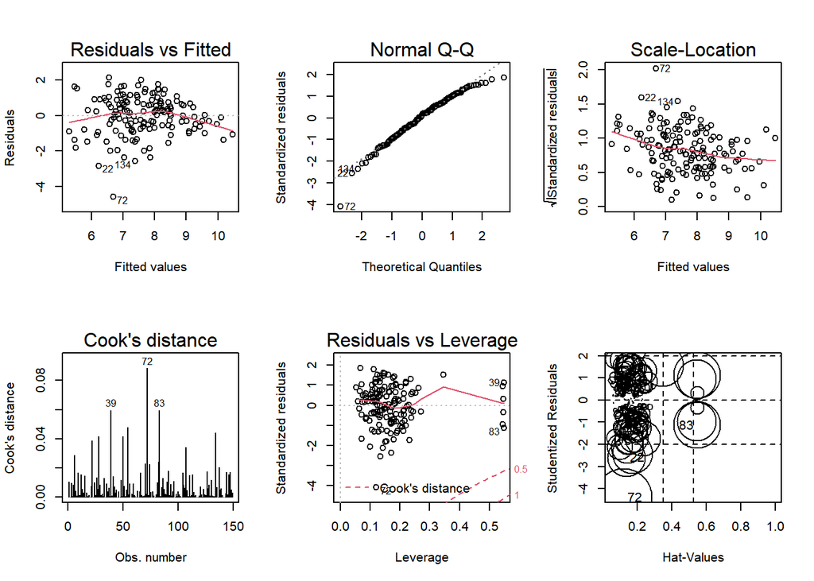

```
## 异常值/强影响点检验
##     rstudent unadjusted p-value Bonferroni p
## 72 -4.383668         2.4886e-05    0.0036831
##
## 异方差检验
## Non-constant Variance Score Test
## Variance formula: ~ fitted.values
## Chisquare = 11.64755, Df = 1, p = 0.00064287
##
##  studentized Breusch-Pagan test
##
## data:  fit
## BP = 20.379, df = 25, p-value = 0.7267
##
##
##  Goldfeld-Quandt test
##
## data:  fit
## GQ = 0.78655, df1 = 49, df2 = 48, p-value = 0.7973
## alternative hypothesis: variance increases from segment 1 to 2
##
##
## 共线性检验
##                  GVIF Df GVIF^(1/(2*Df))
## 类别         6.866912 13        1.076919
## 测试版       1.905239  1        1.380304
## 社交类游戏   1.590688  1        1.261225
## 厂商类别     2.210263  3        1.141320
## 评论平均长度 2.526791  1        1.589588
## 氪金指数     3.310471  1        1.819470
## 爆肝指数     2.331387  1        1.526888
## 游戏机制指数 2.163543  1        1.470899
## 艺术设计指数 1.980552  1        1.407321
## 福利指数     1.704180  1        1.305443
## 广告指数     1.574427  1        1.254762
##
## 自相关检验
##  lag Autocorrelation D-W Statistic p-value
##    1      0.09054341      1.802632    0.21
##  Alternative hypothesis: rho != 0
```

```r
regression.diagnostics(fit.1)
```

初次诊断结果：

下面是处理后的模型。

```r
b <- boxcox(总评分 ~ 类别 + 测试版 + 社交类游戏 + 厂商类别 + 评论平均长度 + 氪金指数 + 爆肝指数 + 游戏机制指数 + 艺术设计指数 + 福利指数 + 广告指数, data = data, plotit = FALSE)
lambda <- b$x[which.max(b$y)]

fit.1 <- lm(formula = 总评分 ^ lambda ~ 类别 + 测试版 + 社交类游戏 + 厂商类别 + 评论平均长度 + 氪金指数 + 爆肝指数 + 游戏机制指数 + 艺术设计指数 + 福利指数 + 广告指数, data = data[-96, ])
summary(fit.1)
```

```
##
## Call:
## lm(formula = 总评分^lambda ~ 类别 + 测试版 + 社交类游戏 + 厂商类别 +
##     评论平均长度 + 氪金指数 + 爆肝指数 + 游戏机制指数 + 艺术设计指数 +
##     福利指数 + 广告指数, data = data[-96, ])
##
## Residuals:
##     Min      1Q  Median      3Q     Max
## -43.923 -10.361   0.499  10.234  32.057
##
## Coefficients:
##                 Estimate Std. Error t value Pr(>|t|)
## (Intercept)     59.19096    7.18827   8.234 2.33e-13 ***
## 类别动作        -2.97561    6.27074  -0.475   0.6360
## 类别角色扮演    -7.58693    5.01820  -1.512   0.1332
## 类别街机         7.69469   12.99916   0.592   0.5550
## 类别竞速        -1.30421   12.83264  -0.102   0.9192
## 类别卡牌        -8.32505    7.70767  -1.080   0.2822
## 类别冒险        -2.89574    6.77795  -0.427   0.6700
## 类别模拟         2.25315    6.28226   0.359   0.7205
## 类别文字        -3.71738    7.98940  -0.465   0.6426
## 类别休闲        -8.03706    6.55783  -1.226   0.2227
## 类别益智         5.98948    7.35956   0.814   0.4173
## 类别音乐        10.67000    9.28490   1.149   0.2527
## 类别知识问答    19.08391   17.59945   1.084   0.2803
## 类别桌面和棋类   3.33347   12.63000   0.264   0.7923
## 测试版是        -3.23249    4.07930  -0.792   0.4297
## 社交类游戏是     5.93527    3.76310   1.577   0.1173
## 厂商类别腾讯   -11.12614    6.84794  -1.625   0.1068
## 厂商类别网易   -12.80693    6.47107  -1.979   0.0501 .
## 厂商类别小厂     1.44086    4.29082   0.336   0.7376
## 评论平均长度     0.01506    0.01884   0.799   0.4257
## 氪金指数       -11.47056    2.44466  -4.692 7.13e-06 ***
## 爆肝指数         2.13322    2.05278   1.039   0.3008
## 游戏机制指数     4.71930    1.98249   2.380   0.0188 *
## 艺术设计指数     4.85144    1.89971   2.554   0.0119 *
## 福利指数         0.47373    1.75451   0.270   0.7876
## 广告指数        -2.53639    1.68555  -1.505   0.1350
## ---
## Signif. codes:  0 '***' 0.001 '**' 0.01 '*' 0.05 '.' 0.1 ' ' 1
##
## Residual standard error: 16.34 on 122 degrees of freedom
## Multiple R-squared:  0.5109, Adjusted R-squared:  0.4107
## F-statistic: 5.098 on 25 and 122 DF,  p-value: 4.533e-10
```

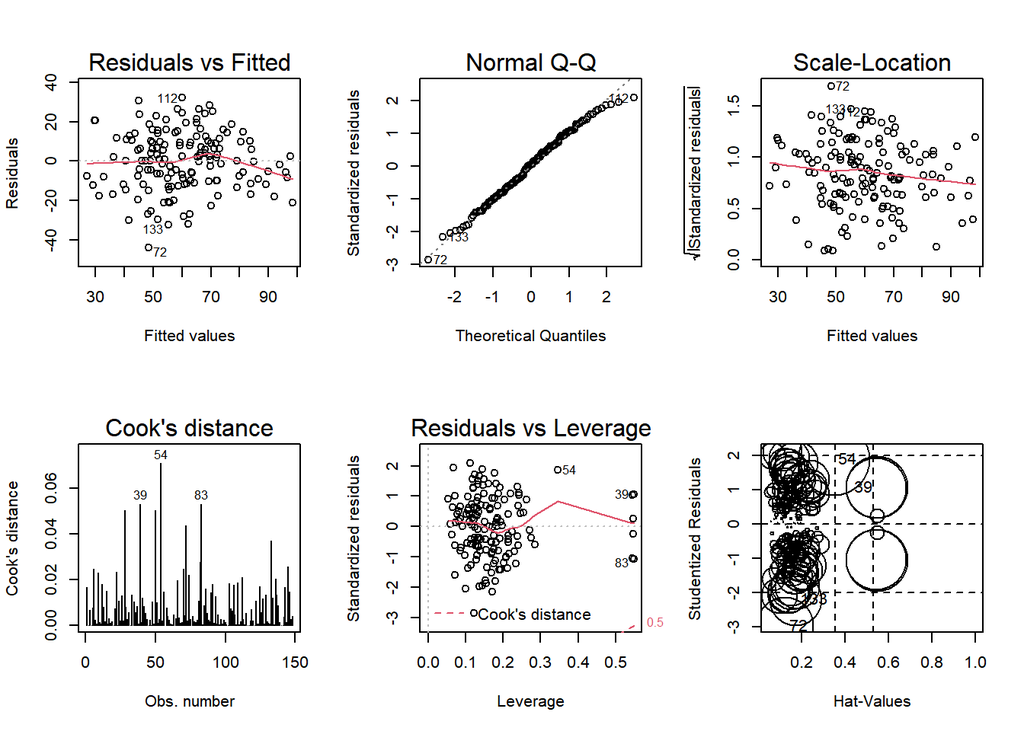

```
## 异常值/强影响点检验
## No Studentized residuals with Bonferroni p < 0.05
## Largest |rstudent|:
##     rstudent unadjusted p-value Bonferroni p
## 72 -2.956697          0.0037397      0.54973
##
## 异方差检验
## Non-constant Variance Score Test
## Variance formula: ~ fitted.values
## Chisquare = 2.354406, Df = 1, p = 0.12493
##
##  studentized Breusch-Pagan test
##
## data:  fit
## BP = 18.068, df = 25, p-value = 0.8395
##
##
##  Goldfeld-Quandt test
##
## data:  fit
## GQ = 0.97803, df1 = 48, df2 = 48, p-value = 0.5305
## alternative hypothesis: variance increases from segment 1 to 2
##
##
## 共线性检验
##                  GVIF Df GVIF^(1/(2*Df))
## 类别         6.472611 13        1.074473
## 测试版       1.900854  1        1.378715
## 社交类游戏   1.595018  1        1.262940
## 厂商类别     2.173529  3        1.138136
## 评论平均长度 2.520731  1        1.587681
## 氪金指数     3.302206  1        1.817197
## 爆肝指数     2.323180  1        1.524198
## 游戏机制指数 2.112388  1        1.453406
## 艺术设计指数 1.853321  1        1.361367
## 福利指数     1.701289  1        1.304335
## 广告指数     1.570857  1        1.253338
##
## 自相关检验
##  lag Autocorrelation D-W Statistic p-value
##    1       0.1021871      1.770931   0.158
##  Alternative hypothesis: rho != 0
```

```r
regression.diagnostics(fit.1)
```

再次诊断结果：

### 模型二（社交类游戏）

因变量：总评分

自变量：测试版 + 厂商类别 + 评论平均长度 + 氪金指数 + 爆肝指数 + 游戏机制指数 + 艺术设计指数 + 福利指数 + 广告指数

```r
fit.2 <- lm(formula = 总评分 ~ 测试版 + 厂商类别 + 评论平均长度 + 氪金指数 + 爆肝指数 + 游戏机制指数 + 艺术设计指数 + 福利指数 + 广告指数, data = data[data$社交类游戏 == "是", ])
summary(fit.2)
```

```
##
## Call:
## lm(formula = 总评分 ~ 测试版 + 厂商类别 + 评论平均长度 + 氪金指数 +
##     爆肝指数 + 游戏机制指数 + 艺术设计指数 + 福利指数 + 广告指数,
##     data = data[data$社交类游戏 == "是", ])
##
## Residuals:
##     Min      1Q  Median      3Q     Max
## -2.3350 -0.9422  0.1910  0.8407  2.0215
##
## Coefficients:
##               Estimate Std. Error t value Pr(>|t|)
## (Intercept)   9.056415   1.090014   8.309 2.84e-09 ***
## 测试版是      3.044790   1.633118   1.864   0.0721 .
## 厂商类别腾讯 -0.849678   0.733399  -1.159   0.2558
## 厂商类别网易 -0.973112   0.672290  -1.447   0.1581
## 厂商类别小厂 -0.381445   0.556942  -0.685   0.4987
## 评论平均长度 -0.004030   0.003836  -1.050   0.3019
## 氪金指数     -0.382107   0.353989  -1.079   0.2890
## 爆肝指数      0.159161   0.269183   0.591   0.5588
## 游戏机制指数  0.459619   0.287889   1.597   0.1209
## 艺术设计指数  0.747931   0.379031   1.973   0.0577 .
## 福利指数      0.088127   0.174651   0.505   0.6175
## 广告指数     -0.472748   0.537752  -0.879   0.3863
## ---
## Signif. codes:  0 '***' 0.001 '**' 0.01 '*' 0.05 '.' 0.1 ' ' 1
##
## Residual standard error: 1.325 on 30 degrees of freedom
## Multiple R-squared:  0.4775, Adjusted R-squared:  0.2859
## F-statistic: 2.493 on 11 and 30 DF,  p-value: 0.02326
```

### 模型三（非社交类游戏）

因变量：总评分

自变量：测试版 + 厂商类别 + 评论平均长度 + 氪金指数 + 爆肝指数 + 游戏机制指数 + 艺术设计指数 + 福利指数 + 广告指数

```r
fit.3 <- lm(formula = 总评分 ~ 测试版 + 厂商类别 + 评论平均长度 + 氪金指数 + 爆肝指数 + 游戏机制指数 + 艺术设计指数 + 福利指数 + 广告指数, data = data[data$社交类游戏 == "否", ][-67, ])
summary(fit.3)
```

```
##
## Call:
## lm(formula = 总评分 ~ 测试版 + 厂商类别 + 评论平均长度 + 氪金指数 +
##     爆肝指数 + 游戏机制指数 + 艺术设计指数 + 福利指数 + 广告指数,
##     data = data[data$社交类游戏 == "否", ][-67, ])
##
## Residuals:
##     Min      1Q  Median      3Q     Max
## -5.1207 -0.6628  0.1475  0.6375  2.1500
##
## Coefficients:
##               Estimate Std. Error t value Pr(>|t|)
## (Intercept)   6.921785   0.498360  13.889  < 2e-16 ***
## 测试版是     -0.530064   0.285218  -1.858   0.0662 .
## 厂商类别腾讯 -0.163775   0.758084  -0.216   0.8294
## 厂商类别网易 -0.429856   0.759790  -0.566   0.5729
## 厂商类别小厂  0.451848   0.357333   1.264   0.2092
## 评论平均长度  0.001781   0.001495   1.191   0.2365
## 氪金指数     -0.986540   0.213261  -4.626 1.19e-05 ***
## 爆肝指数      0.158998   0.167848   0.947   0.3459
## 游戏机制指数  0.272730   0.161233   1.692   0.0940 .
## 艺术设计指数  0.278204   0.122608   2.269   0.0256 *
## 福利指数     -0.208660   0.194737  -1.071   0.2867
## 广告指数     -0.160029   0.111654  -1.433   0.1551
## ---
## Signif. codes:  0 '***' 0.001 '**' 0.01 '*' 0.05 '.' 0.1 ' ' 1
##
## Residual standard error: 1.148 on 94 degrees of freedom
## Multiple R-squared:  0.4635, Adjusted R-squared:  0.4007
## F-statistic: 7.383 on 11 and 94 DF,  p-value: 5.638e-09
```

通过模型二与模型三的对比，我们发现：

### 模型四（高氪游戏）

因变量：总评分

自变量：测试版 + 社交类游戏 + 厂商类别 + 评论平均长度 + 爆肝指数 + 游戏机制指数 + 艺术设计指数 + 福利指数 + 广告指数

```r
fit.4 <- lm(formula = 总评分 ~ 测试版 + 社交类游戏 + 厂商类别 + 评论平均长度 + 爆肝指数 + 游戏机制指数 + 艺术设计指数 + 福利指数 + 广告指数, data = data[data$氪金指数 > quantile(data$氪金指数, 0.75), ][-5, ])
summary(fit.4)
```

```
##
## Call:
## lm(formula = 总评分 ~ 测试版 + 社交类游戏 + 厂商类别 + 评论平均长度 +
##     爆肝指数 + 游戏机制指数 + 艺术设计指数 + 福利指数 + 广告指数,
##     data = data[data$氪金指数 > quantile(data$氪金指数, 0.75),
##         ][-5, ])
##
## Residuals:
##      Min       1Q   Median       3Q      Max
## -2.12197 -1.02614  0.02124  0.83582  2.01699
##
## Coefficients:
##               Estimate Std. Error t value Pr(>|t|)
## (Intercept)   6.467395   1.300993   4.971 4.47e-05 ***
## 测试版是      2.506119   1.437059   1.744   0.0940 .
## 社交类游戏是  0.761899   0.543678   1.401   0.1739
## 厂商类别腾讯  0.350250   0.861394   0.407   0.6879
## 厂商类别网易 -0.886463   0.859139  -1.032   0.3125
## 厂商类别小厂  0.525529   0.633069   0.830   0.4146
## 评论平均长度 -0.003150   0.003551  -0.887   0.3838
## 爆肝指数      0.221339   0.332926   0.665   0.5125
## 游戏机制指数  0.573280   0.343190   1.670   0.1078
## 艺术设计指数  0.744699   0.593858   1.254   0.2219
## 福利指数     -0.046290   0.189597  -0.244   0.8092
## 广告指数     -1.487269   0.699336  -2.127   0.0439 *
## ---
## Signif. codes:  0 '***' 0.001 '**' 0.01 '*' 0.05 '.' 0.1 ' ' 1
##
## Residual standard error: 1.34 on 24 degrees of freedom
## Multiple R-squared:  0.4242, Adjusted R-squared:  0.1602
## F-statistic: 1.607 on 11 and 24 DF,  p-value: 0.1598
```

### 模型五（非高氪游戏）

因变量：总评分

自变量：测试版 + 社交类游戏 + 厂商类别 + 评论平均长度 + 爆肝指数 + 游戏机制指数 + 艺术设计指数 + 福利指数 + 广告指数

```r
fit.5 <- lm(formula = 总评分 ~ 测试版 + 社交类游戏 + 厂商类别 + 评论平均长度 + 爆肝指数 + 游戏机制指数 + 艺术设计指数 + 福利指数 + 广告指数, data = data[data$氪金指数 <= quantile(data$氪金指数, 0.75), ][-c(69, 45), ])
summary(fit.5)
```

```
##
## Call:
## lm(formula = 总评分 ~ 测试版 + 社交类游戏 + 厂商类别 + 评论平均长度 +
##     爆肝指数 + 游戏机制指数 + 艺术设计指数 + 福利指数 + 广告指数,
##     data = data[data$氪金指数 <= quantile(data$氪金指数, 0.75),
##         ][-c(69, 45), ])
##
## Residuals:
##     Min      1Q  Median      3Q     Max
## -5.4449 -0.5875  0.1003  0.6311  2.0877
##
## Coefficients:
##               Estimate Std. Error t value Pr(>|t|)
## (Intercept)   7.686487   0.452844  16.974  < 2e-16 ***
## 测试版是     -0.252955   0.264504  -0.956  0.34126
## 社交类游戏是  0.190931   0.315108   0.606  0.54597
## 厂商类别腾讯 -1.845067   0.608700  -3.031  0.00312 **
## 厂商类别网易 -1.596144   0.558943  -2.856  0.00524 **
## 厂商类别小厂 -0.094923   0.336782  -0.282  0.77865
## 评论平均长度  0.002149   0.001426   1.507  0.13511
## 爆肝指数     -0.226194   0.143737  -1.574  0.11879
## 游戏机制指数  0.175259   0.147177   1.191  0.23661
## 艺术设计指数  0.327835   0.115663   2.834  0.00558 **
## 福利指数     -0.236896   0.158440  -1.495  0.13808
## 广告指数     -0.119687   0.111711  -1.071  0.28663
## ---
## Signif. codes:  0 '***' 0.001 '**' 0.01 '*' 0.05 '.' 0.1 ' ' 1
##
## Residual standard error: 1.113 on 98 degrees of freedom
## Multiple R-squared:  0.3723, Adjusted R-squared:  0.3018
## F-statistic: 5.284 on 11 and 98 DF,  p-value: 1.663e-06
```

## 评论数模型

### 模型六（所有游戏）

因变量：log(总评论数)

自变量：类别 + 测试版 + 厂商类别 + 评论平均长度 + 氪金指数 + 爆肝指数 + 游戏机制指数 + 艺术设计指数 + 福利指数 + 广告指数

```r
fit.6 <- lm(formula = log(总评论数) ~ 类别 + 测试版 + 厂商类别 + 评论平均长度 + 氪金指数 + 爆肝指数 + 游戏机制指数 + 艺术设计指数 + 福利指数 + 广告指数, data = data)
summary(fit.6)
```

```
##
## Call:
## lm(formula = log(总评论数) ~ 类别 + 测试版 + 厂商类别 + 评论平均长度 +
##     氪金指数 + 爆肝指数 + 游戏机制指数 + 艺术设计指数 + 福利指数 +
##     广告指数, data = data)
##
## Residuals:
##      Min       1Q   Median       3Q      Max
## -2.77129 -0.88124 -0.04688  0.93243  3.00991
##
## Coefficients:
##                 Estimate Std. Error t value Pr(>|t|)
## (Intercept)     7.866999   0.580970  13.541  < 2e-16 ***
## 类别动作        1.320012   0.508722   2.595   0.0106 *
## 类别角色扮演   -0.046402   0.410254  -0.113   0.9101
## 类别街机        0.619407   1.064681   0.582   0.5618
## 类别竞速       -0.192221   1.051910  -0.183   0.8553
## 类别卡牌       -0.723743   0.631905  -1.145   0.2543
## 类别冒险       -0.128064   0.555413  -0.231   0.8180
## 类别模拟       -0.269934   0.515076  -0.524   0.6012
## 类别文字        0.056820   0.654786   0.087   0.9310
## 类别休闲        0.305021   0.532058   0.573   0.5675
## 类别益智        0.397964   0.592929   0.671   0.5034
## 类别音乐        1.385637   0.726329   1.908   0.0587 .
## 类别知识问答    1.182574   1.443046   0.819   0.4141
## 类别桌面和棋类 -0.977270   1.035277  -0.944   0.3470
## 测试版是       -1.606632   0.331212  -4.851 3.61e-06 ***
## 厂商类别腾讯   -0.206922   0.560332  -0.369   0.7125
## 厂商类别网易    0.514992   0.527018   0.977   0.3304
## 厂商类别小厂   -0.743566   0.342364  -2.172   0.0318 *
## 评论平均长度    0.006392   0.001543   4.142 6.31e-05 ***
## 氪金指数        0.077202   0.198814   0.388   0.6985
## 爆肝指数       -0.078845   0.167784  -0.470   0.6392
## 游戏机制指数   -0.078258   0.160380  -0.488   0.6264
## 艺术设计指数   -0.220922   0.154010  -1.434   0.1540
## 福利指数        0.048619   0.143148   0.340   0.7347
## 广告指数        0.085187   0.138173   0.617   0.5387
## ---
## Signif. codes:  0 '***' 0.001 '**' 0.01 '*' 0.05 '.' 0.1 ' ' 1
##
## Residual standard error: 1.34 on 124 degrees of freedom
## Multiple R-squared:  0.5833, Adjusted R-squared:  0.5027
## F-statistic: 7.233 on 24 and 124 DF,  p-value: 2.889e-14
```